# JeanReport3

Jean

09/09/2020

## Question 3.1

Here is a step by step guide to Q3.1

1: Simulate 100 observations from a standard normal distribution. Take this as your data

```r
set.seed(2020)
simx = rnorm(100)
```

2: Write a function that computes ISE, so think about if you have two distribution f and g how would you code this up. In practice, you can write a generic function

```r
ISE = function(f, g){
 mean((f - g)^2)
}
```

Alternative functions to consider are:

```
ISE2 =  function(x, f, fhat) {
  integrate(approxfun(x, (f - fhat)^2), lower=-3, upper = 3, subdivisions=512)
}

dx = (xmax-xmin)/(npts-1)
ISE3 = function(f, fhat){
  sum((f - fhat)^2*dx)
}
```

3: Create a grid of potential bandwidth values, this is a vector of bandwidth values, try using the function seq, and use visualization helps you determine the range to investigate

```r
bwgrid = seq(0.01, 0.6, by = 0.02)
```

4. For a given bandwidth, say 0.1, you will need to compute the density estimator and validate it against the known standard normal density measuring its distance by the ISE. Here $n=512$ means that we will generate 512 equally spaced points at which the density is to be estimated. The argument ‘from’ and ‘to’ refers to the left and right-most values. An easy way to understand the effect of each parameter is to change them and see what you get.

```r
## compute the density estimator
estD = density(simx, bw = 0.1, n = 512, from = -3, to=3)

## known standard normal density
knownD = dnorm(estD$x)

## Measure the distance between estD and knownD by
isedistance = ISE(estD$y, knownD)
isedistance
```

```
## [1] 0.003366915
```

Examine the following code to look at what you have created. Make sure you read help(density).

```r
class(estD)
```

```
## [1] "density"
```

```r
head(estD$x)
```

```
## [1] -3.000000 -2.988258 -2.976517 -2.964775 -2.953033 -2.941292
```

```r
head(estD$y)
```

```
## [1] 0.04205587 0.04149574 0.04080877 0.04009711 0.03944113 0.03891078
```

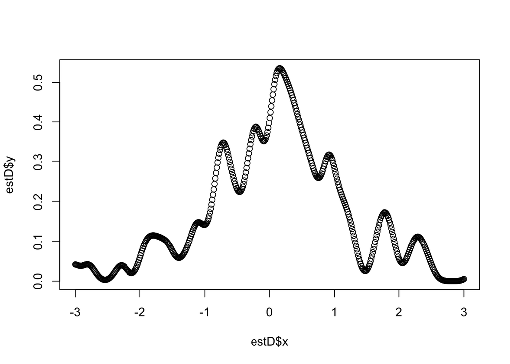

```r
plot(estD$x, estD$y)
```

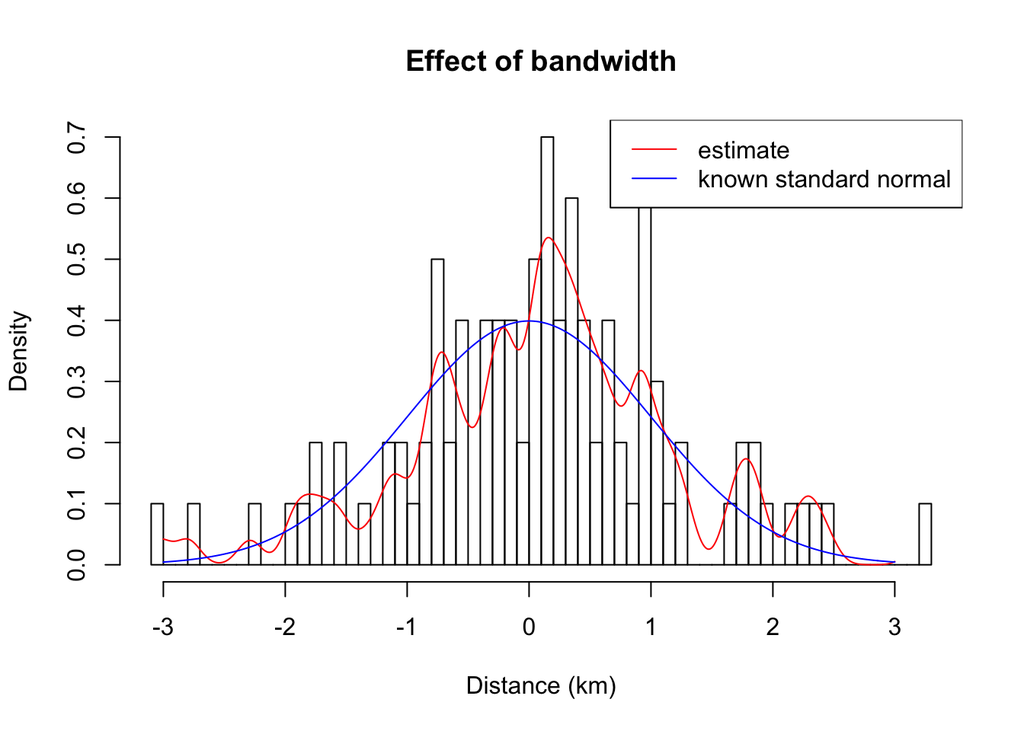

```r
hist(simx, freq = FALSE, breaks = 50, main = "Effect of bandwidth", xlab = "Distance (km)")
lines(estD$x, estD$y, col = "red")
lines(estD$x, dnorm(estD$x), col = "blue")
legend("topright",c("estimate", "known standard normal"), lty=c(1,1), col=c("red", "blue"))
```

5. You will need to repeat step 4 for a series of bandwidth using either a for loop, lapply or sapply functions.

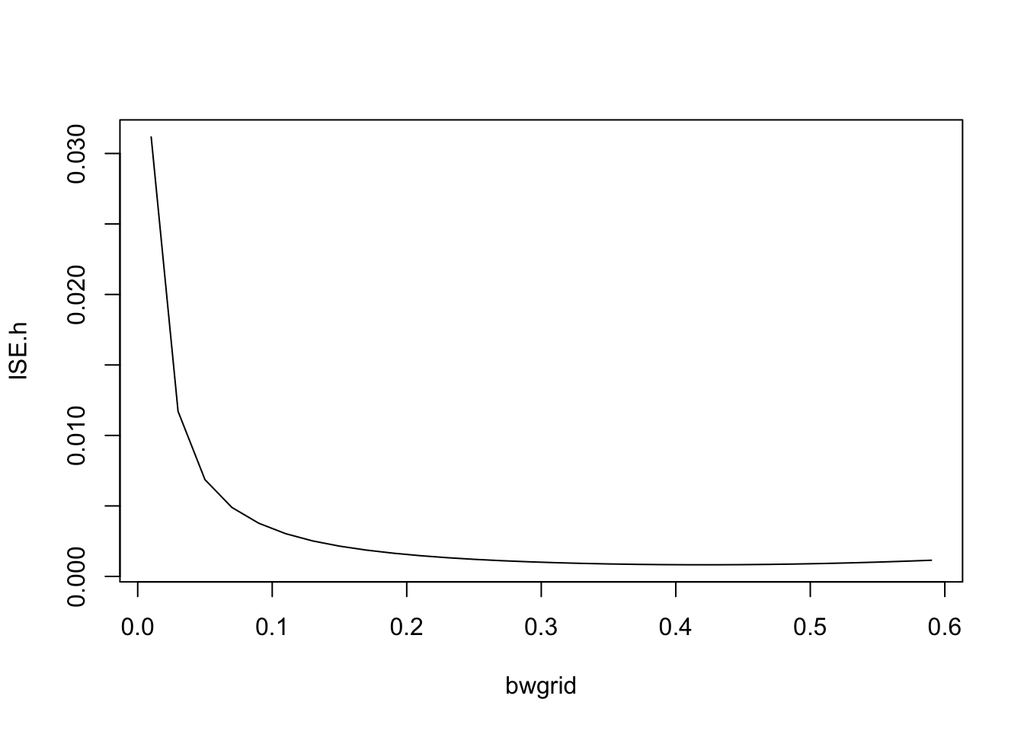

```r
step4 = function(bw)
{
  estD = density(simx, bw = bw, n = 512, from = -3, to=3)
  knownD = dnorm(estD$x)
  return(ISE(estD$y, knownD))
}
ISE.h = sapply(bwgrid, step4)
plot(bwgrid, ISE.h, type="l")
```

6. Find the minimum and plot your final optimal estimate against the true standard normal density for comparison.

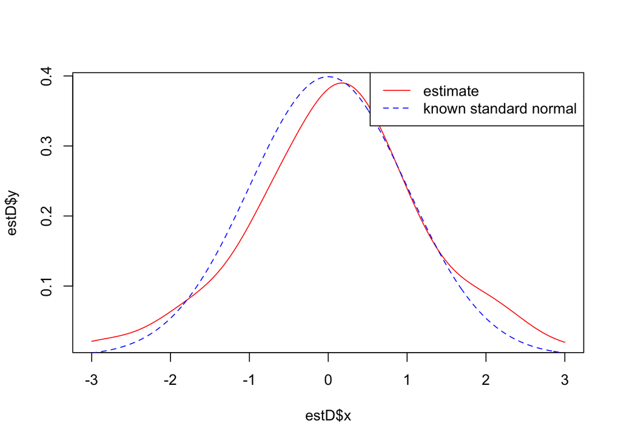

```r
opt.bw <- bwgrid[which.min(ISE.h)]
estD = density(simx, bw = opt.bw , n = 512, from = -3, to=3)
plot(estD$x, estD$y, col = "red", type="l")
lines(estD$x, dnorm(estD$x), col = "blue",lty=2)
legend("topright",c("estimate", "known standard normal"), lty=c(1,2), col=c("red", "blue"))
```